# Analysing trends in Canadian glacers mass

Sergey Sidorov

11/18/2018

## Introduction

This is a first example of my tiny-investigation. For more details of data you can find on http://open.canada.ca/en/open-data[^1].

The data set contains 518 measurments of 6 Canadian glaicer mass balance, collected 1960 till 2007.

Namely, these file includes these glacers:

```
## [1] "Devon Ice Cap NW - Devon Island, Nunavut"
## [2] "Helm Glacier - southern Coast Mountains (Garibaldi Provincial Park), British Columbia"
## [3] "Meighen Ice Cap - Meighen Island, Nunavut"
## [4] "Peyto Glacier - Rocky Mountain eastern slopes (Banff National Park), Alberta"
## [5] "Place Glacier - southern Coast Mountains, British Columbia"
## [6] "White Glacier - Axel Heiberg Island, Nunavut"
```

Among six investigated glaciers the most shorly history has Helm Glacier - southern Coast Mountains (Garibaldi Provincial Park), British Columbia.

Meanwhile median value measurments glacier near about zero namely Meighen Ice Cap - Meighen Island, Nunavut.

Just one NA value measurment has Helm Glacier - southern Coast Mountains (Garibaldi Provincial Park), British Columbia.

## Hypotesis

We are interested in finding out wheter there is a stat.significant change in mass balance over the observed time period. For these purposes we use **R** version (3.5.1) and an appropriate stat test called *t-test*:

$$t = \frac{\overline{x} - mu_0}{s/\sqrt{n}}.$$

The workflow is as follows:

1. Read the file.
2. Run t-test for each glacier and collect p-values.
3. Support the evidence with
   - a table of result;
   - a plot of could help demonstrate results.

## Analysis

Descriptive stats and confidence intervals

[output not shown]

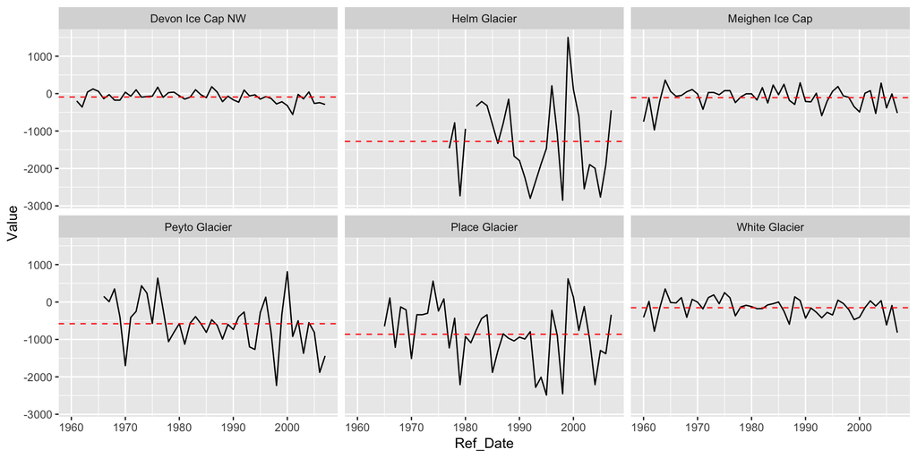

[^1]: Here is the [direct link](https://github.com/tonytonov/Rcourse/blob/master/R%20markdown/demos/glacier.csv) to data download.↩